# What time should I ride my bike?

I’ve computed a metric that calculates the percentage of minutes that there’s changes in the station.

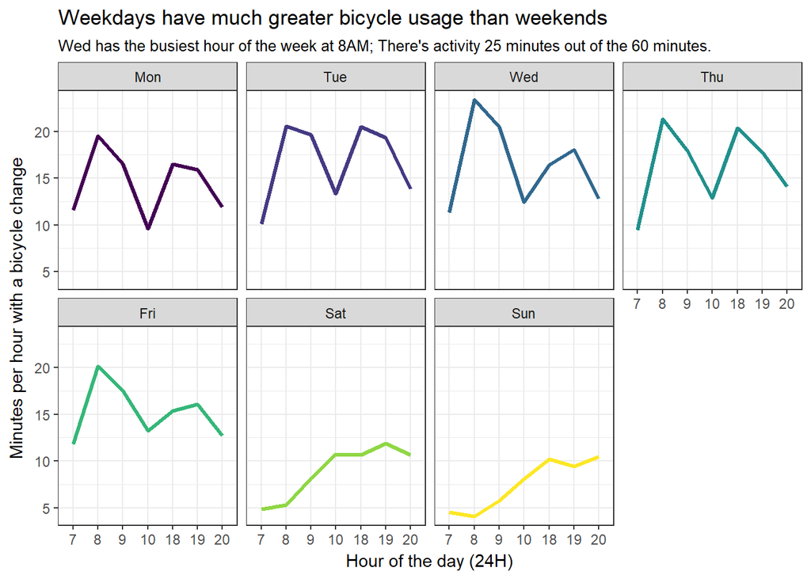

```r
intm_df <-
  bicing %>%
  mutate(hour = as.factor(lubridate::hour(time)),
         day = lubridate::wday(time, label = TRUE, week_start = TRUE)) %>%
  group_by(hour, day) %>%
  mutate(future_bike = lag(bikes)) %>%
  summarize(avg_movement = mean(bikes != future_bike, na.rm = TRUE) * 60) %>%
  ungroup()

intm_df %>%
  ggplot(aes(hour, avg_movement, colour = day, group = day)) +
  geom_line(size = 1.2) +
  facet_wrap(~ day, ncol = 4) +
  theme_bw() +
  labs(x = 'Hour of the day (24H)',
       y = "Minutes per hour with a bicycle change",
       title = 'Weekdays have much greater bicycle usage than weekends',
       subtitle = "Wed has the busiest hour of the week at 8AM; There's activity 25 minutes out of the 60 minutes.") +
  theme(legend.position = 'none')
```

This is very interesting! This plot reverses some of the findings from before. First off, we see that there’s high variability between hours: there’s no point in looking at averages within an hour because a lot happens between minutes. For example, at 7AM and 10 AM during working days there’s very little activity regardless of the day. On the contrary, 8AM and 9AM have high bycicle usage through the working days.

This makes sense, it’s the time that people usually go to work. Also as expected, bicycle usage is low on weekend mornings and increases linearly through out the day. All in all, 8/9 AM on working days seems to be the time to avoid bicycles if you can! Eventually, in another post, I plan to investigate whether there’s minute-to-minute patterns for 8/9 AM on working days. For example, is there more activity closer to certain minutes? Like half past the hour or at exactly the hour.

To begin the conclusion, when are the moments when the station is empty? This will trigger me to avoid picking bicycles on those specific times.

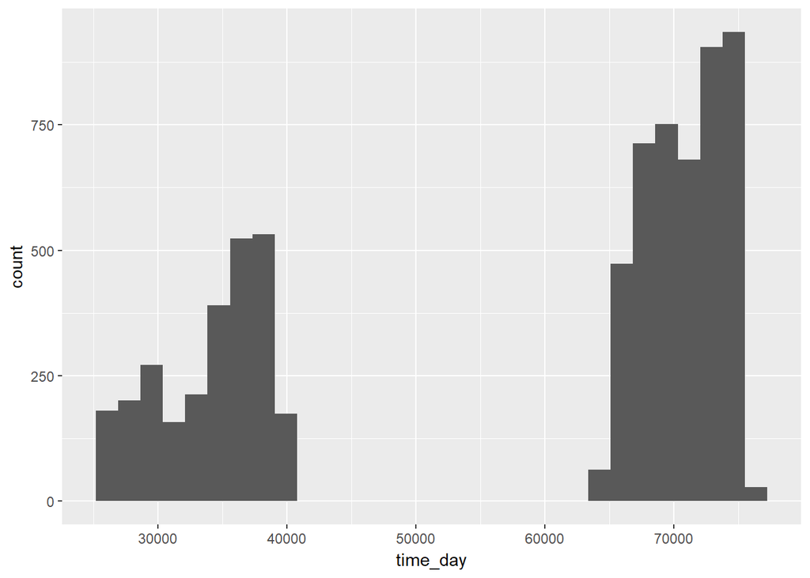

```r
bicing %>%
  filter(bikes == 0) %>%
  mutate(time_day = as.numeric(lubridate::hm(str_extract(time, "[0-9]{2}:[0-9]{2}")))) %>%
  ggplot(aes(x = time_day)) +
  geom_histogram()
```

Bicing people probably prepare very well because it’s mostly empty in the evenings

The next step in the analysis is to start making predictions in waiting time. That will be the topic of my next post, in which I start to develop a modelling approach to predict the time you’ll have to have wait until a bicycle arrives or leaves. As a very simple exercise, I wanted to predict check whether I can predict when the station will be empty? I tried a simple logistic regression just to check.

```r
empty_bicycle <-
  mutate(bicing,
         empty = ifelse(bikes == 0, 1, 0),
         hour = as.character(lubridate::hour(time)),
         day = lubridate::wday(time),
         day = as.character(day)) %>%
  select(-(1:4))

training_rows <- createDataPartition(empty_bicycle$empty, 1, p = 0.8)[[1]]

training <- empty_bicycle[training_rows, ]
test <- empty_bicycle[-training_rows, ]

mod1 <- glm(empty ~ . + day:hour, data = training, family = "binomial")

pred1 <- predict(mod1, newdata = test, type = 'response')

pred_empty <- rbinom(length(pred1), 1, prob = pred1)

confusionMatrix(test$empty, pred_empty, positive = "1")
```

```
## Confusion Matrix and Statistics
##
##           Reference
## Prediction    0    1
##          0 6733 1121
##          1 1135  290
##
##                Accuracy : 0.7569
##                  95% CI : (0.748, 0.7656)
##     No Information Rate : 0.8479
##     P-Value [Acc > NIR] : 1.0000
##
##                   Kappa : 0.061
##  Mcnemar's Test P-Value : 0.7843
##
##             Sensitivity : 0.20553
##             Specificity : 0.85574
##          Pos Pred Value : 0.20351
##          Neg Pred Value : 0.85727
##              Prevalence : 0.15206
##          Detection Rate : 0.03125
##    Detection Prevalence : 0.15357
##       Balanced Accuracy : 0.53064
##
##        'Positive' Class : 1
##
```

This model is terrible at predicting the emptyness of the stations as it can only predict 20% of the time. A few strategies I could check out to improve accuracy:

- Feature engineer when the bicing team picks up bicycles (because they leave them empty)
- Add more information on weather and public holidays from public API’s
- Because the cell that contains empty stations has very few cases, it might be useful to resample that sample until it reaches a similar sample size as the other cells. This might give greater certainty and I assume that there’s not a lot of variability in the pattern of empty stations, so it should be representative.

Finally, other classification models are certainly warranted. One good alternative would be a random forest, as it takes into consideration specific thresholds in the time of day when prunning the trees.

However, we also need to be aware that a model is as good as the data that’s being fit. Perhaps, we just need better data!